# SERP Difficulty via Token Overlap

**Question:** Do SERPs where results look more alike produce different foraging behavior?

**Difficulty metric:** Mean pairwise Jaccard similarity across all result token sets on a SERP. High overlap = results are hard to discriminate = harder SERP.

**Dependent variables:**

1. Trial duration (first event to click)
2. Scroll regression count
3. Click position (do users satisfice earlier on hard SERPs?)
4. Fixation count (total investment)
5. Page coverage (how far down do they scan?)
6. Per-result dwell curve shape (flat vs declining)

**Key difference from serp_priming.ipynb:** That notebook asked whether overlap predicts *speed* at each position (priming hypothesis — null result). This notebook asks whether SERP-level difficulty changes the *strategy*.

**Dataset:** AdSERP — 2,776 trials, 47 participants, product purchase queries. Each participant gets a unique SERP snapshot from Google, so difficulty varies even within the same query.

```python
import os, re, csv, json
import xml.etree.ElementTree as ET
from pathlib import Path
from collections import defaultdict

import numpy as np
import matplotlib.pyplot as plt
from scipy import stats
from bs4 import BeautifulSoup

plt.rcParams.update({
    'figure.figsize': (12, 6),
    'figure.dpi': 150,
    'font.size': 11,
    'axes.titlesize': 13,
    'axes.labelsize': 11,
})

# Ensure cwd is project root
if not os.path.exists('AdSERP') and os.path.exists('../AdSERP'):
    os.chdir('..')

DATA_DIR = 'AdSERP/data'
SERP_DIR = os.path.join(DATA_DIR, 'serps')
FIXATION_DIR = os.path.join(DATA_DIR, 'fixation-data')
MOUSE_DIR = os.path.join(DATA_DIR, 'mouse-movement-data')
METADATA_DIR = os.path.join(DATA_DIR, 'trial-metadata')

serp_files = sorted(Path(SERP_DIR).glob('*.html')) if os.path.exists(SERP_DIR) else []
print(f'SERP HTML files: {len(serp_files)}')

# Load trial catalog
with open(os.path.join(DATA_DIR, 'interesting-trials.json')) as f:
    catalog = json.load(f)
trial_meta = {t['trial_id']: t for t in catalog['trials']}
print(f'Trial catalog: {len(trial_meta)} trials')
```

```
SERP HTML files: 2776
Trial catalog: 2341 trials
```

## Step 1: Extract SERP text and compute difficulty

Reuses the tokenization from serp_priming.ipynb. Difficulty = mean pairwise Jaccard across all result pairs on a SERP.

```python
STOPWORDS = set('the a an and or but in on at to for of is it this that was were be been '
                'being have has had do does did will would shall should may might can could '
                'with from by as are not no its my your his her their our its '
                'between both during each few how more most other some such through until '
                'where which while who whom why into over under'.split())

def tokenize(text):
    """Simple whitespace + punctuation tokenizer, lowercased, stopwords removed."""
    tokens = re.findall(r'[a-z0-9]+', text.lower())
    return [t for t in tokens if t not in STOPWORDS and len(t) > 1]

def extract_serp_results(html_path):
    """Extract ordered list of search results from a Google SERP HTML file."""
    with open(html_path, 'r', encoding='utf-8', errors='ignore') as f:
        soup = BeautifulSoup(f.read(), 'html.parser')

    results = []
    rso = soup.find(id='rso')
    if not rso:
        rso = soup

    for i, h3 in enumerate(rso.find_all('h3')):
        title_text = h3.get_text(strip=True)
        container = h3.parent
        for _ in range(5):
            if container and container.parent:
                container = container.parent
                if container.name == 'div':
                    if container.get('class') and any('g' in c for c in container.get('class', [])):
                        break

        snippet_parts = []
        if container:
            for text_elem in container.find_all(['span', 'div'], recursive=True):
                text = text_elem.get_text(strip=True)
                if text and text != title_text and len(text) > 20:
                    snippet_parts.append(text)

        link = h3.find_parent('a')
        url = link.get('href', '') if link else ''

        all_text = title_text + ' ' + ' '.join(snippet_parts[:3])
        tokens = tokenize(all_text)

        results.append({
            'position': i,
            'title': title_text,
            'tokens': tokens,
            'token_set': set(tokens),
        })

    return results

def compute_serp_difficulty(results):
    """Mean pairwise Jaccard similarity across all result pairs.

    Higher = more overlap = harder to discriminate.
    """
    pairwise = []
    for i in range(len(results)):
        for j in range(i + 1, len(results)):
            ti = results[i]['token_set']
            tj = results[j]['token_set']
            union = ti | tj
            if union:
                pairwise.append(len(ti & tj) / len(union))
    return np.mean(pairwise) if pairwise else 0.0

# Process all SERPs
print('Extracting SERP text and computing difficulty...')
serp_difficulty = {}  # trial_id -> difficulty score
serp_n_results = {}   # trial_id -> number of results
errors = 0

for html_path in serp_files:
    tid = html_path.stem
    try:
        results = extract_serp_results(html_path)
        if len(results) >= 3:
            serp_difficulty[tid] = compute_serp_difficulty(results)
            serp_n_results[tid] = len(results)
    except:
        errors += 1

diffs = np.array(list(serp_difficulty.values()))
print(f'Processed: {len(serp_difficulty)} SERPs ({errors} errors)')
print(f'Difficulty: mean={diffs.mean():.3f}, median={np.median(diffs):.3f}, std={diffs.std():.3f}')
print(f'Range: [{diffs.min():.3f}, {diffs.max():.3f}]')
```

```
Extracting SERP text and computing difficulty...
```

```
Processed: 2772 SERPs (0 errors)
Difficulty: mean=0.151, median=0.150, std=0.033
Range: [0.029, 0.395]
```

## Step 2: Link difficulty to behavioral measures

For each trial with both SERP difficulty and behavioral data, collect DVs from the catalog and raw data files.

```python
def get_click_position(trial_id):
    """Get Y-position of first click from mouse data."""
    path = os.path.join(MOUSE_DIR, f'{trial_id}.csv')
    if not os.path.exists(path):
        return None
    with open(path) as f:
        for row in csv.DictReader(f):
            if row['event'] == 'click':
                return float(row['ypos'])
    return None

def count_regressions(trial_id):
    """Count scroll regressions (upward scrolls after a downward scroll)."""
    path = os.path.join(MOUSE_DIR, f'{trial_id}.csv')
    if not os.path.exists(path):
        return None
    scrolls = []
    with open(path) as f:
        for row in csv.DictReader(f):
            if row['event'] == 'scroll':
                scrolls.append(float(row['ypos']))
    if len(scrolls) < 2:
        return 0
    regressions = 0
    prev_direction = None
    for i in range(1, len(scrolls)):
        dy = scrolls[i] - scrolls[i-1]
        if dy < -5:  # upward scroll (regression)
            direction = 'up'
        elif dy > 5:
            direction = 'down'
        else:
            continue
        if direction == 'up' and prev_direction == 'down':
            regressions += 1
        prev_direction = direction
    return regressions

# Build linked dataset
trials = []
for tid, diff in serp_difficulty.items():
    meta = trial_meta.get(tid)
    if not meta:
        continue

    click_y = get_click_position(tid)
    n_regressions = count_regressions(tid)

    if meta['duration_s'] < 1 or meta['duration_s'] > 120:
        continue

    trials.append({
        'trial_id': tid,
        'participant': meta['participant'],
        'difficulty': diff,
        'n_results': serp_n_results[tid],
        'duration_s': meta['duration_s'],
        'fixation_count': meta['fixation_count'],
        'page_coverage_pct': meta['page_coverage_pct'],
        'n_regressions': n_regressions if n_regressions is not None else 0,
        'has_regression': meta['has_scroll_regression'],
        'click_y': click_y,
        'scroll_count': meta['scroll_event_count'],
    })

print(f'Linked trials: {len(trials)}')

# Convert to arrays for easy slicing
diff_arr = np.array([t['difficulty'] for t in trials])
dur_arr = np.array([t['duration_s'] for t in trials])
fix_arr = np.array([t['fixation_count'] for t in trials])
cov_arr = np.array([t['page_coverage_pct'] for t in trials])
reg_arr = np.array([t['n_regressions'] for t in trials])
click_arr = np.array([t['click_y'] if t['click_y'] else np.nan for t in trials])
```

```
Linked trials: 2334
```

## Step 3: Difficulty distribution and correlations

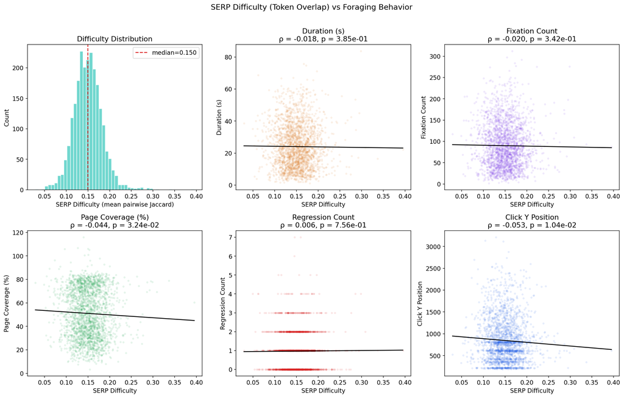

```python
fig, axes = plt.subplots(2, 3, figsize=(16, 10))

# 1: Difficulty distribution
ax = axes[0, 0]
ax.hist(diff_arr, bins=50, color='#4ecdc4', alpha=0.8, edgecolor='white')
ax.axvline(np.median(diff_arr), color='#dc2626', linestyle='--', label=f'median={np.median(diff_arr):.3f}')
ax.set_xlabel('SERP Difficulty (mean pairwise Jaccard)')
ax.set_ylabel('Count')
ax.set_title('Difficulty Distribution')
ax.legend()

# Correlations for remaining 5 panels
dvs = [
    ('Duration (s)', dur_arr, '#e07c24'),
    ('Fixation Count', fix_arr, '#7c3aed'),
    ('Page Coverage (%)', cov_arr, '#16a34a'),
    ('Regression Count', reg_arr, '#dc2626'),
    ('Click Y Position', click_arr, '#2563eb'),
]

for idx, (label, arr, color) in enumerate(dvs):
    ax = axes[(idx + 1) // 3, (idx + 1) % 3]
    mask = np.isfinite(arr)
    x, y = diff_arr[mask], arr[mask]

    ax.scatter(x, y, alpha=0.08, s=8, color=color, rasterized=True)

    # Regression line
    r, p = stats.spearmanr(x, y)
    slope, intercept = np.polyfit(x, y, 1)
    x_line = np.linspace(x.min(), x.max(), 100)
    ax.plot(x_line, slope * x_line + intercept, color='black', linewidth=1.5)

    ax.set_xlabel('SERP Difficulty')
    ax.set_ylabel(label)
    ax.set_title(f'{label}\n\u03c1 = {r:.3f}, p = {p:.2e}')

plt.suptitle('SERP Difficulty (Token Overlap) vs Foraging Behavior', fontsize=14, y=1.01)
plt.tight_layout()
plt.savefig('plot_difficulty_overview.png', dpi=200, bbox_inches='tight')
plt.show()
```

## Step 4: Tercile comparison

Split SERPs into easy / medium / hard by difficulty terciles. Compare behavioral profiles.

```python
t1, t2 = np.percentile(diff_arr, [33, 66])
groups = {
    'Easy (low overlap)': [t for t in trials if t['difficulty'] <= t1],
    'Medium': [t for t in trials if t1 < t['difficulty'] <= t2],
    'Hard (high overlap)': [t for t in trials if t['difficulty'] > t2],
}

print(f'Tercile boundaries: {t1:.3f}, {t2:.3f}')
print(f'Group sizes: {" / ".join(f"{k}: {len(v)}" for k, v in groups.items())}\n')

metrics = ['duration_s', 'fixation_count', 'page_coverage_pct', 'n_regressions']
metric_labels = ['Duration (s)', 'Fixation Count', 'Page Coverage (%)', 'Regressions']

print(f'{"":>22s}  {"Easy":>10s}  {"Medium":>10s}  {"Hard":>10s}   KW p-value')
print('-' * 72)

for metric, label in zip(metrics, metric_labels):
    vals = {name: [t[metric] for t in group] for name, group in groups.items()}
    means = {name: np.mean(v) for name, v in vals.items()}

    # Kruskal-Wallis test (non-parametric)
    h_stat, p_val = stats.kruskal(*vals.values())
    sig = '***' if p_val < 0.001 else '**' if p_val < 0.01 else '*' if p_val < 0.05 else ''

    m = list(means.values())
    print(f'{label:>22s}  {m[0]:10.2f}  {m[1]:10.2f}  {m[2]:10.2f}   {p_val:.4f} {sig}')

# Click Y position (has NaNs)
vals_click = {name: [t['click_y'] for t in group if t['click_y'] is not None]
              for name, group in groups.items()}
means_click = {name: np.mean(v) for name, v in vals_click.items()}
h, p = stats.kruskal(*vals_click.values())
sig = '***' if p < 0.001 else '**' if p < 0.01 else '*' if p < 0.05 else ''
m = list(means_click.values())
print(f'{"Click Y Position":>22s}  {m[0]:10.1f}  {m[1]:10.1f}  {m[2]:10.1f}   {p:.4f} {sig}')

# Regression rate (proportion with at least one regression)
for name, group in groups.items():
    rate = np.mean([t['has_regression'] for t in group])
    print(f'  {name} regression rate: {rate:.1%}')
```

```
Tercile boundaries: 0.136, 0.162
Group sizes: Easy (low overlap): 770 / Medium: 770 / Hard (high overlap): 794

                              Easy      Medium        Hard   KW p-value
------------------------------------------------------------------------
          Duration (s)       24.48       23.58       24.09   0.4996
        Fixation Count       92.27       87.97       89.78   0.3016
     Page Coverage (%)       52.33       50.48       50.31   0.1241
           Regressions        0.98        0.95        0.98   0.9233
      Click Y Position       877.0       847.4       817.0   0.1008
  Easy (low overlap) regression rate: 64.4%
  Medium regression rate: 65.7%
  Hard (high overlap) regression rate: 65.6%
```

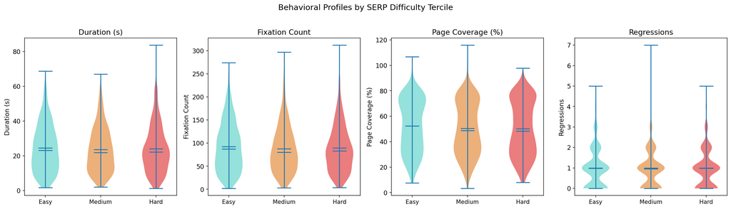

```python
fig, axes = plt.subplots(1, 4, figsize=(18, 5))
colors = ['#4ecdc4', '#e07c24', '#dc2626']
labels = list(groups.keys())

for idx, (metric, mlabel) in enumerate(zip(metrics, metric_labels)):
    ax = axes[idx]
    data = [[t[metric] for t in groups[name]] for name in labels]

    parts = ax.violinplot(data, positions=[1, 2, 3], showmeans=True, showmedians=True)
    for i, pc in enumerate(parts['bodies']):
        pc.set_facecolor(colors[i])
        pc.set_alpha(0.6)

    ax.set_xticks([1, 2, 3])
    ax.set_xticklabels(['Easy', 'Medium', 'Hard'], fontsize=10)
    ax.set_ylabel(mlabel)
    ax.set_title(mlabel)

plt.suptitle('Behavioral Profiles by SERP Difficulty Tercile', fontsize=14, y=1.02)
plt.tight_layout()
plt.savefig('plot_difficulty_terciles.png', dpi=200, bbox_inches='tight')
plt.show()
```

## Step 5: Confound check — difficulty vs number of results

SERPs with more results mechanically have higher pairwise overlap (more token sharing opportunities). Check if difficulty is just a proxy for result count.

```python
nresults_arr = np.array([t['n_results'] for t in trials])

r_dn, p_dn = stats.spearmanr(diff_arr, nresults_arr)
print(f'Difficulty x n_results: rho = {r_dn:.3f}, p = {p_dn:.2e}')

# Partial correlation: difficulty -> DV, controlling for n_results
# Using residualization approach
def partial_spearman(x, y, z):
    """Spearman correlation between x and y, controlling for z."""
    # Rank-transform then residualize
    rx = stats.rankdata(x)
    ry = stats.rankdata(y)
    rz = stats.rankdata(z)

    # Residualize x and y against z
    slope_xz = np.polyfit(rz, rx, 1)[0]
    slope_yz = np.polyfit(rz, ry, 1)[0]
    rx_resid = rx - slope_xz * rz
    ry_resid = ry - slope_yz * rz

    return stats.pearsonr(rx_resid, ry_resid)

print('\nPartial correlations (difficulty -> DV, controlling for n_results):')
for label, arr in [('Duration', dur_arr), ('Fixations', fix_arr),
                    ('Coverage', cov_arr), ('Regressions', reg_arr)]:
    r, p = partial_spearman(diff_arr, arr, nresults_arr)
    sig = '***' if p < 0.001 else '**' if p < 0.01 else '*' if p < 0.05 else ''
    print(f'  {label:>12s}: r = {r:.4f}, p = {p:.4f} {sig}')

# Click Y with NaN handling
mask = np.isfinite(click_arr)
r, p = partial_spearman(diff_arr[mask], click_arr[mask], nresults_arr[mask])
sig = '***' if p < 0.001 else '**' if p < 0.01 else '*' if p < 0.05 else ''
print(f'  {"Click Y":>12s}: r = {r:.4f}, p = {p:.4f} {sig}')
```

```
Difficulty x n_results: rho = -0.028, p = 1.74e-01

Partial correlations (difficulty -> DV, controlling for n_results):
      Duration: r = -0.0185, p = 0.3710
     Fixations: r = -0.0201, p = 0.3316
      Coverage: r = -0.0463, p = 0.0252 *
   Regressions: r = 0.0062, p = 0.7654
       Click Y: r = -0.0544, p = 0.0086 **
```

## Step 6: Within-participant effects

```python
# Group trials by participant
by_participant = defaultdict(list)
for t in trials:
    by_participant[t['participant']].append(t)

# Per-participant correlations between difficulty and DVs
within_corrs = defaultdict(list)  # metric -> [per-participant rho]

for pid, ptrials in by_participant.items():
    if len(ptrials) < 5:  # need enough trials for meaningful correlation
        continue

    pdiff = [t['difficulty'] for t in ptrials]

    for metric in ['duration_s', 'fixation_count', 'n_regressions', 'page_coverage_pct']:
        vals = [t[metric] for t in ptrials]
        if np.std(pdiff) > 0 and np.std(vals) > 0:
            r, _ = stats.spearmanr(pdiff, vals)
            if np.isfinite(r):
                within_corrs[metric].append(r)

print('Within-participant correlations (difficulty -> DV):')
print(f'{"Metric":>20s}  {"Mean rho":>9s}  {"t":>7s}  {"p":>9s}  N')
print('-' * 60)

for metric, label in zip(['duration_s', 'fixation_count', 'n_regressions', 'page_coverage_pct'],
                          ['Duration', 'Fixations', 'Regressions', 'Coverage']):
    corrs = within_corrs[metric]
    mean_r = np.mean(corrs)
    # One-sample t-test: is mean rho different from 0?
    t_stat, p_val = stats.ttest_1samp(corrs, 0)
    sig = '***' if p_val < 0.001 else '**' if p_val < 0.01 else '*' if p_val < 0.05 else ''
    print(f'{label:>20s}  {mean_r:9.3f}  {t_stat:7.2f}  {p_val:9.4f}  {len(corrs)} {sig}')
```

```
Within-participant correlations (difficulty -> DV):
              Metric   Mean rho        t          p  N
------------------------------------------------------------
            Duration     -0.023    -1.18     0.2431  47
           Fixations     -0.020    -1.00     0.3217  47
         Regressions      0.002     0.07     0.9433  46
            Coverage     -0.048    -2.15     0.0365  47 *
```

## Summary

Interpret results above. Key questions:

1. Does SERP difficulty (token overlap) predict *any* behavioral measure at the between-trial level?
2. Do the effects survive controlling for number of results?
3. Are effects visible within-participant (ruling out individual-difference confounds)?

If effects are null at bag-of-words Jaccard, next step is semantic similarity (embeddings) per the TODO.

## Step 7: Reading Episode Analysis

The GP3 HD's internal I-DT filter reports pre-segmented fixations (~220ms mean). But consecutive fixations on the **same result** connected by **minor saccades** (<100px) represent continuous reading — the parafovea was preprocessing the next landing during each fixation. We pool these into **reading episodes**.

An episode starts when gaze arrives at a result and ends when a **major saccade** (>100px) leaves it or gaze moves to a different result. Episode duration includes inter-fixation saccade gaps (parafoveal preview time).

**Question:** Do hard SERPs (high token overlap) produce different episode structure? More fixations per episode (re-reading to find distinguishing features)? Longer episodes?

```python
from bisect import bisect_right

MINOR_SACCADE_THRESHOLD = 100  # pixels

def get_trial_meta_xml(trial_id):
    path = os.path.join(METADATA_DIR, f'{trial_id}.xml')
    try:
        tree = ET.parse(path)
        doc_h = int(tree.find('.//document').text.split('x')[1])
        return doc_h
    except:
        return None

def count_results_html(trial_id):
    path = os.path.join(SERP_DIR, f'{trial_id}.html')
    if not os.path.exists(path):
        return 0
    with open(path, encoding='utf-8', errors='replace') as f:
        soup = BeautifulSoup(f.read(), 'html.parser')
    return len(soup.find_all('h3'))

def result_bands(n_results, doc_height):
    header = 200
    per_res = (doc_height - 400) / max(n_results, 1)
    return [header + i * per_res for i in range(n_results)]

def interpolate_scroll(t, scroll_ts, scroll_ys):
    if not scroll_ts: return 0.0
    if t <= scroll_ts[0]: return scroll_ys[0]
    if t >= scroll_ts[-1]: return scroll_ys[-1]
    idx = bisect_right(scroll_ts, t) - 1
    if idx < len(scroll_ts) - 1:
        frac = (t - scroll_ts[idx]) / max(scroll_ts[idx+1] - scroll_ts[idx], 1)
        return scroll_ys[idx] + frac * (scroll_ys[idx+1] - scroll_ys[idx])
    return scroll_ys[-1]

def compute_episodes(trial_id):
    """Load fixations, assign to result bands, pool into reading episodes.

    Returns list of episodes, each: {pos, n_fixations, duration_ms, fixations}
    """
    doc_h = get_trial_meta_xml(trial_id)
    if not doc_h: return None
    n_res = count_results_html(trial_id)
    if n_res < 3: return None

    tops = result_bands(n_res, doc_h)

    # Load scroll timeline
    scroll_ts, scroll_ys = [], []
    mouse_path = os.path.join(MOUSE_DIR, f'{trial_id}.csv')
    if os.path.exists(mouse_path):
        with open(mouse_path) as f:
            for row in csv.DictReader(f):
                if row['event'] == 'scroll':
                    scroll_ts.append(float(row['timestamp']))
                    scroll_ys.append(float(row['ypos']))

    # Load fixations
    fix_path = os.path.join(FIXATION_DIR, f'{trial_id}.csv')
    if not os.path.exists(fix_path): return None
    fixations = []
    with open(fix_path) as f:
        for row in csv.DictReader(f):
            try:
                t = float(row['timestamp'])
                x = float(row['FPOGX'])
                y = float(row['FPOGY'])
                d = float(row['FPOGD'])
                if d < 60: continue  # filter sub-threshold artifacts
                page_y = y + interpolate_scroll(t, scroll_ts, scroll_ys)
                pos = bisect_right(tops, page_y) - 1
                pos = max(0, min(pos, n_res - 1))
                fixations.append({'t': t, 'x': x, 'y': y, 'd': d, 'pos': pos})
            except:
                continue

    if not fixations: return None

    # Pool into episodes
    episodes = []
    current = [fixations[0]]

    for i in range(1, len(fixations)):
        prev, curr = fixations[i-1], fixations[i]
        amp = ((curr['x'] - prev['x'])**2 + (curr['y'] - prev['y'])**2) ** 0.5

        if curr['pos'] == prev['pos'] and amp < MINOR_SACCADE_THRESHOLD:
            current.append(curr)
        else:
            episodes.append(current)
            current = [curr]
    episodes.append(current)

    result = []
    for ep in episodes:
        ep_start = ep[0]['t'] - ep[0]['d']  # t is end time
        ep_end = ep[-1]['t']
        result.append({
            'pos': ep[0]['pos'],
            'n_fixations': len(ep),
            'duration_ms': ep_end - ep_start,
            'sum_fpogd': sum(f['d'] for f in ep),
        })
    return result

# Compute episodes for all trials with difficulty scores
print('Computing reading episodes...')
trial_episodes = {}  # trial_id -> episode list
for i, t in enumerate(trials):
    tid = t['trial_id']
    eps = compute_episodes(tid)
    if eps:
        trial_episodes[tid] = eps
    if (i + 1) % 500 == 0:
        print(f'  {i+1}/{len(trials)}...')

print(f'Trials with episodes: {len(trial_episodes)}')

# Aggregate stats
all_ep_nfix = []
all_ep_dur = []
for eps in trial_episodes.values():
    for ep in eps:
        all_ep_nfix.append(ep['n_fixations'])
        all_ep_dur.append(ep['duration_ms'])

all_ep_nfix = np.array(all_ep_nfix)
all_ep_dur = np.array(all_ep_dur)

print(f'\nTotal episodes: {len(all_ep_nfix)}')
print(f'Fixations per episode: mean={all_ep_nfix.mean():.2f}, median={np.median(all_ep_nfix):.0f}')
print(f'  Single-fixation: {(all_ep_nfix == 1).mean()*100:.1f}%')
print(f'  2 fixations: {(all_ep_nfix == 2).mean()*100:.1f}%')
print(f'  3+ fixations: {(all_ep_nfix >= 3).mean()*100:.1f}%')
print(f'Episode duration: mean={all_ep_dur.mean():.0f}ms, median={np.median(all_ep_dur):.0f}ms')
```

```
Computing reading episodes...
```

```
  500/2334...
```

```
  1000/2334...
```

```
  1500/2334...
```

```
  2000/2334...
```

```
Trials with episodes: 2334

Total episodes: 95328
Fixations per episode: mean=2.16, median=1
  Single-fixation: 50.5%
  2 fixations: 23.1%
  3+ fixations: 26.4%
Episode duration: mean=499ms, median=336ms
```

## Step 8: Episode structure by SERP difficulty

Do hard SERPs produce more fixations per episode (re-reading within results to find distinguishing features)?

```python
# Per-trial episode metrics
episode_trials = []
for t in trials:
    tid = t['trial_id']
    if tid not in trial_episodes: continue
    eps = trial_episodes[tid]

    nfix_per_ep = [ep['n_fixations'] for ep in eps]
    dur_per_ep = [ep['duration_ms'] for ep in eps]
    multi_fix = [ep for ep in eps if ep['n_fixations'] > 1]

    episode_trials.append({
        'trial_id': tid,
        'difficulty': t['difficulty'],
        'n_episodes': len(eps),
        'mean_fix_per_ep': np.mean(nfix_per_ep),
        'mean_ep_duration': np.mean(dur_per_ep),
        'pct_multi_fixation': len(multi_fix) / len(eps) if eps else 0,
        'mean_fix_in_multi': np.mean([ep['n_fixations'] for ep in multi_fix]) if multi_fix else 0,
        'n_raw_fixations': sum(nfix_per_ep),
        # Parafoveal bonus: total episode duration minus sum of FPOGD
        'parafoveal_ms': sum(ep['duration_ms'] - ep['sum_fpogd'] for ep in eps),
    })

print(f'Trials with episode metrics: {len(episode_trials)}')

# Correlations
ep_diff = np.array([t['difficulty'] for t in episode_trials])
ep_metrics = {
    'Episodes/trial': np.array([t['n_episodes'] for t in episode_trials]),
    'Fix/episode': np.array([t['mean_fix_per_ep'] for t in episode_trials]),
    'Episode duration (ms)': np.array([t['mean_ep_duration'] for t in episode_trials]),
    '% multi-fixation': np.array([t['pct_multi_fixation'] for t in episode_trials]),
    'Fix in multi-ep': np.array([t['mean_fix_in_multi'] for t in episode_trials]),
    'Parafoveal time (ms)': np.array([t['parafoveal_ms'] for t in episode_trials]),
}

print(f'\n{"Metric":>25s}  {"Mean":>8s}  {"rho":>7s}  {"p":>10s}')
print('-' * 58)
for name, arr in ep_metrics.items():
    r, p = stats.spearmanr(ep_diff, arr)
    sig = '***' if p < 0.001 else '**' if p < 0.01 else '*' if p < 0.05 else ''
    print(f'{name:>25s}  {arr.mean():8.2f}  {r:7.3f}  {p:10.4f} {sig}')
```

```
Trials with episode metrics: 2334

                   Metric      Mean      rho           p
----------------------------------------------------------
           Episodes/trial     40.84   -0.020      0.3286
              Fix/episode      2.17    0.024      0.2411
    Episode duration (ms)    507.31    0.018      0.3778
         % multi-fixation      0.50    0.051      0.0131 *
          Fix in multi-ep      3.29   -0.002      0.9244
     Parafoveal time (ms)    866.17   -0.012      0.5553
```

```
                 Episodes per Trial: Easy=41.88  Med=40.27  Hard=40.39  p=0.3471
              Fixations per Episode: Easy=2.17  Med=2.15  Hard=2.20  p=0.2052
              Episode Duration (ms): Easy=505.13  Med=499.77  Hard=516.73  p=0.1590
          % Multi-Fixation Episodes: Easy=0.49  Med=0.49  Hard=0.51  p=0.0042 **
    Fixations in Multi-Fix Episodes: Easy=3.31  Med=3.27  Hard=3.30  p=0.7294
         Total Parafoveal Time (ms): Easy=878.06  Med=876.77  Hard=844.37  p=0.8206
```

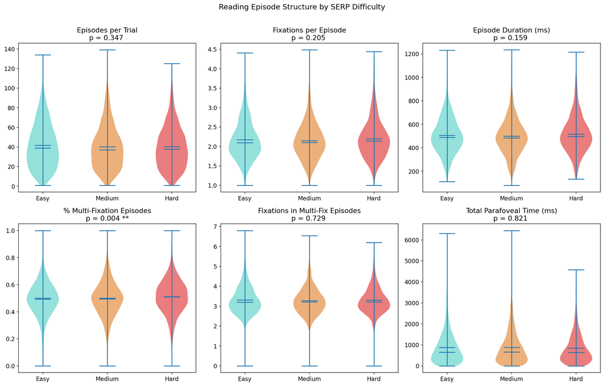

```python
# Tercile comparison for episode metrics
t1, t2 = np.percentile(ep_diff, [33, 66])
ep_groups = {
    'Easy': [t for t in episode_trials if t['difficulty'] <= t1],
    'Medium': [t for t in episode_trials if t1 < t['difficulty'] <= t2],
    'Hard': [t for t in episode_trials if t['difficulty'] > t2],
}

fig, axes = plt.subplots(2, 3, figsize=(16, 10))
colors = {'Easy': '#4ecdc4', 'Medium': '#e07c24', 'Hard': '#dc2626'}

metric_keys = ['n_episodes', 'mean_fix_per_ep', 'mean_ep_duration',
               'pct_multi_fixation', 'mean_fix_in_multi', 'parafoveal_ms']
metric_titles = ['Episodes per Trial', 'Fixations per Episode', 'Episode Duration (ms)',
                  '% Multi-Fixation Episodes', 'Fixations in Multi-Fix Episodes', 'Total Parafoveal Time (ms)']

for idx, (key, title) in enumerate(zip(metric_keys, metric_titles)):
    ax = axes[idx // 3, idx % 3]
    data = [[t[key] for t in ep_groups[g]] for g in ['Easy', 'Medium', 'Hard']]

    parts = ax.violinplot(data, positions=[1, 2, 3], showmeans=True, showmedians=True)
    for i, pc in enumerate(parts['bodies']):
        pc.set_facecolor(list(colors.values())[i])
        pc.set_alpha(0.6)

    # Kruskal-Wallis
    h, p = stats.kruskal(*data)
    sig = '***' if p < 0.001 else '**' if p < 0.01 else '*' if p < 0.05 else ''

    ax.set_xticks([1, 2, 3])
    ax.set_xticklabels(['Easy', 'Medium', 'Hard'])
    ax.set_title(f'{title}\np = {p:.3f} {sig}')

    # Print means
    means = [np.mean(d) for d in data]
    print(f'{title:>35s}: Easy={means[0]:.2f}  Med={means[1]:.2f}  Hard={means[2]:.2f}  p={p:.4f} {sig}')

plt.suptitle('Reading Episode Structure by SERP Difficulty', fontsize=14, y=1.01)
plt.tight_layout()
plt.savefig('plot_difficulty_episodes.png', dpi=200, bbox_inches='tight')
plt.show()
```

## Step 9: Episode structure by position x difficulty

The most interesting prediction: on hard SERPs, users need **more fixations per episode at every position** because results share vocabulary and require deeper reading to discriminate. On easy SERPs, a single fixation per result may suffice to identify the unique one.

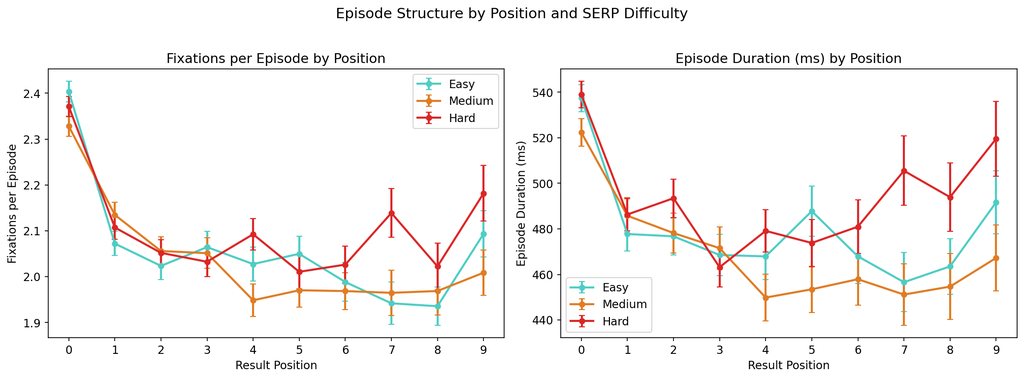

```
 Pos   Easy nfix   Hard nfix    Easy dur    Hard dur
----------------------------------------------------
   0        2.40        2.37         537         539
   1        2.07        2.11         478         486
   2        2.02        2.05         477         493
   3        2.06        2.03         469         463
   4        2.03        2.09         468         479
   5        2.05        2.01         488         474
   6        1.99        2.03         468         481
   7        1.94        2.14         457         506
   8        1.94        2.02         464         494
   9        2.09        2.18         492         520
```

```python
# Per-position episode metrics, split by difficulty tercile
max_pos = 10

# Accumulate per-position, per-difficulty-group
pos_data = {g: {p: {'nfix': [], 'dur': []} for p in range(max_pos)}
            for g in ['Easy', 'Medium', 'Hard']}

for t in episode_trials:
    tid = t['trial_id']
    diff = t['difficulty']
    if diff <= t1: group = 'Easy'
    elif diff <= t2: group = 'Medium'
    else: group = 'Hard'

    for ep in trial_episodes[tid]:
        pos = ep['pos']
        if pos < max_pos:
            pos_data[group][pos]['nfix'].append(ep['n_fixations'])
            pos_data[group][pos]['dur'].append(ep['duration_ms'])

fig, axes = plt.subplots(1, 2, figsize=(14, 5))
positions = list(range(max_pos))

for ax, metric, ylabel in [(axes[0], 'nfix', 'Fixations per Episode'),
                            (axes[1], 'dur', 'Episode Duration (ms)')]:
    for group, color in colors.items():
        means = [np.mean(pos_data[group][p][metric]) if pos_data[group][p][metric] else 0
                 for p in positions]
        sems = [np.std(pos_data[group][p][metric]) / max(len(pos_data[group][p][metric])**0.5, 1)
                if pos_data[group][p][metric] else 0 for p in positions]
        ax.errorbar(positions, means, yerr=sems, marker='o', label=group,
                    color=color, capsize=3, linewidth=2, markersize=5)

    ax.set_xlabel('Result Position')
    ax.set_ylabel(ylabel)
    ax.set_title(ylabel + ' by Position')
    ax.legend()
    ax.set_xticks(positions)

plt.suptitle('Episode Structure by Position and SERP Difficulty', fontsize=14, y=1.02)
plt.tight_layout()
plt.savefig('plot_difficulty_episodes_by_position.png', dpi=200, bbox_inches='tight')
plt.show()

# Print the table
print(f'{"Pos":>4s}  {"Easy nfix":>10s}  {"Hard nfix":>10s}  {"Easy dur":>10s}  {"Hard dur":>10s}')
print('-' * 52)
for p in positions:
    en = np.mean(pos_data['Easy'][p]['nfix']) if pos_data['Easy'][p]['nfix'] else 0
    hn = np.mean(pos_data['Hard'][p]['nfix']) if pos_data['Hard'][p]['nfix'] else 0
    ed = np.mean(pos_data['Easy'][p]['dur']) if pos_data['Easy'][p]['dur'] else 0
    hd = np.mean(pos_data['Hard'][p]['dur']) if pos_data['Hard'][p]['dur'] else 0
    print(f'{p:4d}  {en:10.2f}  {hn:10.2f}  {ed:10.0f}  {hd:10.0f}')
```

## Episode Analysis Summary

**What episode pooling adds:** Raw fixation analysis treats each ~220ms fixation as independent. Episode pooling recognizes that consecutive fixations on the same result connected by minor saccades (<100px) form continuous reading events. The parafovea preprocesses upcoming content during each fixation, so the inter-saccade gap isn't a processing break.

**Key metrics:**

- **Fixations per episode:** How much re-reading within a result? Higher = harder to extract meaning.
- **% multi-fixation episodes:** What fraction of result encounters require more than one look?
- **Parafoveal time:** Total inter-fixation gap time within episodes — processing time not captured by summing FPOGD.

**Interpretation depends on results above.** If hard SERPs produce more fixations per episode, the token overlap metric is capturing something real about discriminability that the coarser behavioral measures (duration, regression count) miss.

## Step 10: Better Difficulty Measures

Bag-of-words Jaccard is the wrong lens for transactional product queries — results *should* share vocabulary. Two conceptually grounded alternatives:

1. **Relevance spread** (std of query-result cosine similarity, mxbai-embed-large): Low spread = all results equidistant from query = no obvious best answer = hard.
2. **Distinctive feature density** (mean TF-IDF-weighted unique-token fraction): Low density = results lack distinguishing features = hard.

Precomputed by `scripts/compute_difficulty_measures.py`.

**Key correlation between measures:**

- Jaccard vs Spread: rho = -0.450 (strongly anti-correlated — different constructs)
- Jaccard vs Density: rho = -0.077 (nearly independent)
- Density vs Spread: rho = 0.103 (weakly related)

```python
# Load precomputed difficulty measures
with open(os.path.join(DATA_DIR, 'serp-difficulty-measures.json')) as f:
    difficulty_measures = json.load(f)

# Merge with trial data
trials_v2 = []
for t in trials:
    tid = t['trial_id']
    if tid not in difficulty_measures:
        continue
    dm = difficulty_measures[tid]
    if dm['relevance_spread'] is None:
        continue
    t2 = dict(t)
    t2['relevance_spread'] = dm['relevance_spread']
    t2['distinctive_density'] = dm['distinctive_density']
    t2['jaccard'] = dm['jaccard']
    trials_v2.append(t2)

print(f'Trials with all three measures: {len(trials_v2)}')

spread_arr = np.array([t['relevance_spread'] for t in trials_v2])
density_arr = np.array([t['distinctive_density'] for t in trials_v2])
jaccard_arr = np.array([t['jaccard'] for t in trials_v2])
dur_v2 = np.array([t['duration_s'] for t in trials_v2])
fix_v2 = np.array([t['fixation_count'] for t in trials_v2])
cov_v2 = np.array([t['page_coverage_pct'] for t in trials_v2])
reg_v2 = np.array([t['n_regressions'] for t in trials_v2])
click_v2 = np.array([t['click_y'] if t['click_y'] else np.nan for t in trials_v2])
```

```
Trials with all three measures: 2334
```

```python
# Test all three difficulty measures against all behavioral DVs
measures = [
    ('Jaccard (token overlap)', jaccard_arr),
    ('Relevance Spread (std)', spread_arr),
    ('Distinctive Density', density_arr),
]

dvs = [
    ('Duration (s)', dur_v2),
    ('Fixation Count', fix_v2),
    ('Coverage (%)', cov_v2),
    ('Regressions', reg_v2),
    ('Click Y', click_v2),
]

# Note: for Spread and Density, the DIFFICULTY direction is inverted:
# Low spread = hard, Low density = hard (positive rho = easier SERPs → more of DV)
# For Jaccard: High = hard (positive rho = harder SERPs → more of DV)

print(f'{"":>28s}', end='')
for dv_name, _ in dvs:
    print(f'  {dv_name:>14s}', end='')
print()
print('-' * (28 + 16 * len(dvs)))

for m_name, m_arr in measures:
    print(f'{m_name:>28s}', end='')
    for dv_name, dv_arr in dvs:
        mask = np.isfinite(dv_arr)
        r, p = stats.spearmanr(m_arr[mask], dv_arr[mask])
        sig = '***' if p < 0.001 else '**' if p < 0.01 else '*' if p < 0.05 else ''
        print(f'  {r:+.3f}{sig:>4s}    ', end='')
    print()

print(f'\n(N = {len(trials_v2)})')
print('Spread & Density: positive rho = EASIER SERPs produce more of DV')
print('Jaccard: positive rho = HARDER SERPs produce more of DV')
```

```
                                Duration (s)  Fixation Count    Coverage (%)     Regressions         Click Y
------------------------------------------------------------------------------------------------------------
     Jaccard (token overlap)  -0.019          -0.021          -0.046   *      +0.005          -0.055  **
      Relevance Spread (std)  +0.043   *      +0.047   *      +0.098 ***      +0.035          +0.046   *
         Distinctive Density  +0.014          +0.015          +0.071 ***      +0.004          -0.052   *

(N = 2334)
Spread & Density: positive rho = EASIER SERPs produce more of DV
Jaccard: positive rho = HARDER SERPs produce more of DV
```

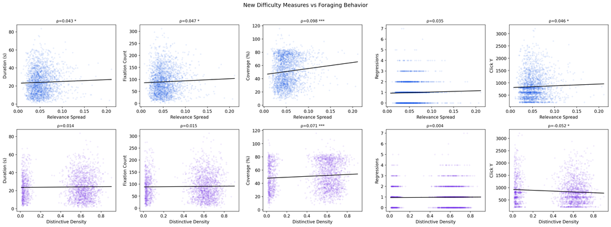

```python
# Scatter plots: new measures vs behavioral DVs
fig, axes = plt.subplots(2, 5, figsize=(22, 8))

# Row 0: Relevance Spread
# Row 1: Distinctive Density
new_measures = [
    ('Relevance Spread', spread_arr, '#2563eb'),
    ('Distinctive Density', density_arr, '#7c3aed'),
]

for row, (m_name, m_arr, m_color) in enumerate(new_measures):
    for col, (dv_name, dv_arr) in enumerate(dvs):
        ax = axes[row, col]
        mask = np.isfinite(dv_arr)
        x, y = m_arr[mask], dv_arr[mask]

        ax.scatter(x, y, alpha=0.08, s=8, color=m_color, rasterized=True)

        r, p = stats.spearmanr(x, y)
        slope, intercept = np.polyfit(x, y, 1)
        x_line = np.linspace(x.min(), x.max(), 100)
        ax.plot(x_line, slope * x_line + intercept, color='black', linewidth=1.5)

        ax.set_xlabel(m_name)
        ax.set_ylabel(dv_name)
        sig = '***' if p < 0.001 else '**' if p < 0.01 else '*' if p < 0.05 else ''
        ax.set_title(f'\u03c1={r:.3f} {sig}', fontsize=10)

plt.suptitle('New Difficulty Measures vs Foraging Behavior', fontsize=14, y=1.01)
plt.tight_layout()
plt.savefig('plot_difficulty_new_measures.png', dpi=200, bbox_inches='tight')
plt.show()
```

```python
# Tercile analysis for Relevance Spread (most promising conceptually)
s1, s2 = np.percentile(spread_arr, [33, 66])
spread_groups = {
    'Hard (low spread)': [t for t in trials_v2 if t['relevance_spread'] <= s1],
    'Medium': [t for t in trials_v2 if s1 < t['relevance_spread'] <= s2],
    'Easy (high spread)': [t for t in trials_v2 if t['relevance_spread'] > s2],
}

print(f'Relevance Spread terciles: {s1:.4f}, {s2:.4f}')
print(f'Group sizes: {" / ".join(f"{k}: {len(v)}" for k, v in spread_groups.items())}\n')

all_metrics = ['duration_s', 'fixation_count', 'page_coverage_pct', 'n_regressions']
all_labels = ['Duration (s)', 'Fixation Count', 'Coverage (%)', 'Regressions']

print(f'{"":>22s}  {"Hard":>10s}  {"Medium":>10s}  {"Easy":>10s}   KW p-value')
print('-' * 72)

for metric, label in zip(all_metrics, all_labels):
    vals = {name: [t[metric] for t in group] for name, group in spread_groups.items()}
    means = {name: np.mean(v) for name, v in vals.items()}
    h, p = stats.kruskal(*vals.values())
    sig = '***' if p < 0.001 else '**' if p < 0.01 else '*' if p < 0.05 else ''
    m = list(means.values())
    print(f'{label:>22s}  {m[0]:10.2f}  {m[1]:10.2f}  {m[2]:10.2f}   {p:.4f} {sig}')

# Click Y
vals_c = {name: [t['click_y'] for t in group if t['click_y'] is not None]
          for name, group in spread_groups.items()}
means_c = [np.mean(v) for v in vals_c.values()]
h, p = stats.kruskal(*vals_c.values())
sig = '***' if p < 0.001 else '**' if p < 0.01 else '*' if p < 0.05 else ''
print(f'{"Click Y":>22s}  {means_c[0]:10.1f}  {means_c[1]:10.1f}  {means_c[2]:10.1f}   {p:.4f} {sig}')

# Also test density terciles
d1, d2 = np.percentile(density_arr, [33, 66])
density_groups = {
    'Hard (low density)': [t for t in trials_v2 if t['distinctive_density'] <= d1],
    'Medium': [t for t in trials_v2 if d1 < t['distinctive_density'] <= d2],
    'Easy (high density)': [t for t in trials_v2 if t['distinctive_density'] > d2],
}

print(f'\nDistinctive Density terciles: {d1:.4f}, {d2:.4f}')
print(f'Group sizes: {" / ".join(f"{k}: {len(v)}" for k, v in density_groups.items())}\n')

print(f'{"":>22s}  {"Hard":>10s}  {"Medium":>10s}  {"Easy":>10s}   KW p-value')
print('-' * 72)

for metric, label in zip(all_metrics, all_labels):
    vals = {name: [t[metric] for t in group] for name, group in density_groups.items()}
    means = {name: np.mean(v) for name, v in vals.items()}
    h, p = stats.kruskal(*vals.values())
    sig = '***' if p < 0.001 else '**' if p < 0.01 else '*' if p < 0.05 else ''
    m = list(means.values())
    print(f'{label:>22s}  {m[0]:10.2f}  {m[1]:10.2f}  {m[2]:10.2f}   {p:.4f} {sig}')

vals_c2 = {name: [t['click_y'] for t in group if t['click_y'] is not None]
           for name, group in density_groups.items()}
means_c2 = [np.mean(v) for v in vals_c2.values()]
h, p = stats.kruskal(*vals_c2.values())
sig = '***' if p < 0.001 else '**' if p < 0.01 else '*' if p < 0.05 else ''
print(f'{"Click Y":>22s}  {means_c2[0]:10.1f}  {means_c2[1]:10.1f}  {means_c2[2]:10.1f}   {p:.4f} {sig}')
```

```
Relevance Spread terciles: 0.0409, 0.0574
Group sizes: Hard (low spread): 770 / Medium: 770 / Easy (high spread): 794

                              Hard      Medium        Easy   KW p-value
------------------------------------------------------------------------
          Duration (s)       23.53       24.28       24.33   0.2858
        Fixation Count       88.18       89.93       91.84   0.2359
          Coverage (%)       49.01       50.72       53.29   0.0002 ***
           Regressions        0.96        0.95        0.99   0.5459
               Click Y       814.4       855.8       869.6   0.0470 *

Distinctive Density terciles: 0.4904, 0.6257
Group sizes: Hard (low density): 770 / Medium: 770 / Easy (high density): 794

                              Hard      Medium        Easy   KW p-value
------------------------------------------------------------------------
          Duration (s)       23.74       24.43       23.98   0.5743
        Fixation Count       88.85       91.37       89.80   0.6000
          Coverage (%)       48.65       52.27       52.14   0.0004 ***
           Regressions        0.96        1.00        0.95   0.4486
               Click Y       901.6       824.5       815.3   0.0246 *
```

```python
# Within-participant effects for new measures
by_part_v2 = defaultdict(list)
for t in trials_v2:
    by_part_v2[t['participant']].append(t)

for m_name, m_key in [('Relevance Spread', 'relevance_spread'),
                       ('Distinctive Density', 'distinctive_density')]:
    print(f'\nWithin-participant: {m_name} -> DV')
    print(f'{"Metric":>20s}  {"Mean rho":>9s}  {"t":>7s}  {"p":>9s}  N')
    print('-' * 58)

    for metric, label in zip(['duration_s', 'fixation_count', 'n_regressions', 'page_coverage_pct'],
                              ['Duration', 'Fixations', 'Regressions', 'Coverage']):
        corrs = []
        for pid, ptrials in by_part_v2.items():
            if len(ptrials) < 5: continue
            pm = [t[m_key] for t in ptrials]
            pv = [t[metric] for t in ptrials]
            if np.std(pm) > 0 and np.std(pv) > 0:
                r, _ = stats.spearmanr(pm, pv)
                if np.isfinite(r):
                    corrs.append(r)

        if corrs:
            mean_r = np.mean(corrs)
            t_stat, p_val = stats.ttest_1samp(corrs, 0)
            sig = '***' if p_val < 0.001 else '**' if p_val < 0.01 else '*' if p_val < 0.05 else ''
            print(f'{label:>20s}  {mean_r:9.3f}  {t_stat:7.2f}  {p_val:9.4f}  {len(corrs)} {sig}')
```

```
Within-participant: Relevance Spread -> DV
              Metric   Mean rho        t          p  N
----------------------------------------------------------
            Duration      0.042     2.22     0.0311  47 *
           Fixations      0.031     1.64     0.1083  47
         Regressions      0.032     1.62     0.1131  46
            Coverage      0.089     3.90     0.0003  47 ***

Within-participant: Distinctive Density -> DV
              Metric   Mean rho        t          p  N
----------------------------------------------------------
            Duration      0.013     0.51     0.6117  47
           Fixations      0.016     0.66     0.5096  47
         Regressions      0.013     0.74     0.4660  46
            Coverage      0.089     3.85     0.0004  47 ***
```